# Data Scientist Professional Practical Exam

**David Galera.**

## Data validation

- recipe: 947 unique identifiers without missing values, same as the description. No cleaning is needed.
- calories: 52 missing values, the variable has a right skewed distribution so I used the median to impute the missing values.
- carbohydrate: 52 missing values, the variable has a right skewed distribution so I used the median to impute the missing values.
- sugar: 52 missing values, the variable has a right skewed distribution so I used the median to impute the missing values.
- protein: 52 missing values, the variable has a right skewed distribution so I used the median to impute the missing values.
- category: No missing values, I have replaced value 'Chicken Breast' with the correct string and I have converted the column dtype to categorical nominal.
- servings: No missing values, I have replaced values ['4 as a snack', '6 as a snack'] with the correct string and I have converted the column dtype to integer.
- high_traffic: Same as description. The target is binary so I have replaced 'High' value with 1 and null values with 0.

```python
# Start coding here...
import pandas as pd
import numpy as np
import matplotlib.pyplot as plt
import matplotlib.style as style
import seaborn as sns
plt.style.use('ggplot')
```

```python
df = pd.read_csv('recipe_site_traffic_2212.csv')
df.info()
```

```
<class 'pandas.core.frame.DataFrame'>
RangeIndex: 947 entries, 0 to 946
Data columns (total 8 columns):
 #   Column        Non-Null Count  Dtype
---  ------        --------------  -----
 0   recipe        947 non-null    int64
 1   calories      895 non-null    float64
 2   carbohydrate  895 non-null    float64
 3   sugar         895 non-null    float64
 4   protein       895 non-null    float64
 5   category      947 non-null    object
 6   servings      947 non-null    object
 7   high_traffic  574 non-null    object
dtypes: float64(4), int64(1), object(3)
memory usage: 59.3+ KB
```

```python
df.head()
```

|  | recipe | calories | carbohydrate | sugar | protein | category | servings | high_traffic |
| --- | --- | --- | --- | --- | --- | --- | --- | --- |
| 0 | 1 | NaN | NaN | NaN | NaN | Pork | 6 | High |
| 1 | 2 | 35.48 | 38.56 | 0.66 | 0.92 | Potato | 4 | High |
| 2 | 3 | 914.28 | 42.68 | 3.09 | 2.88 | Breakfast | 1 | NaN |
| 3 | 4 | 97.03 | 30.56 | 38.63 | 0.02 | Beverages | 4 | High |
| 4 | 5 | 27.05 | 1.85 | 0.80 | 0.53 | Beverages | 4 | NaN |

```python
#validate 947 unique identifiers
df.recipe.nunique()
```

```
947
```

```python
#check number of missing values in the calories variable
df.calories.isna().sum()
```

```
52
```

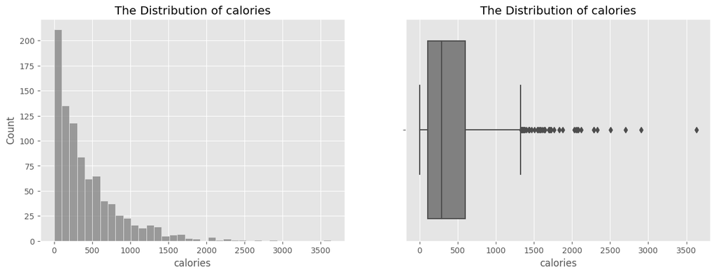

```python
#check calories variable distribution
fig, axes = plt.subplots(1,2,figsize=(15,5))
sns.histplot(x=df['calories'],ax=axes[0],color='gray').set(title='The Distribution of calories')
sns.boxplot(x=df['calories'],color='gray',ax=axes[1]).set(title='The Distribution of calories');
```

```python
#impute median for calories variable missing values
df.loc[df['calories'].isnull(),'calories']=df['calories'].median()
df.calories.isna().sum()
```

```
0
```

```python
#check number of missing values in the carbohydrate variable
df.carbohydrate.isna().sum()
```

```
52
```

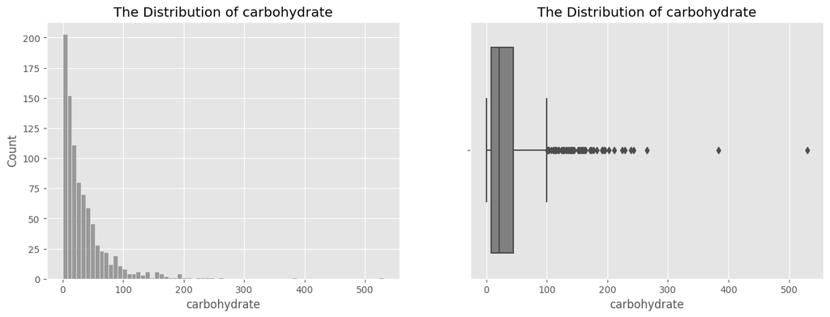

```python
#check carbohydrate variable distribution
fig, axes = plt.subplots(1,2,figsize=(15,5))
sns.histplot(x=df['carbohydrate'],ax=axes[0],color='gray').set(title='The Distribution of carbohydrate')
sns.boxplot(x=df['carbohydrate'],color='gray',ax=axes[1]).set(title='The Distribution of carbohydrate');
```

```python
#impute median for carbohydrate variable missing values
df.loc[df['carbohydrate'].isnull(),'carbohydrate']=df['carbohydrate'].median()
df.carbohydrate.isna().sum()
```

```
0
```

```python
#check number of missing values in the sugar variable
df.sugar.isna().sum()
```

```
52
```

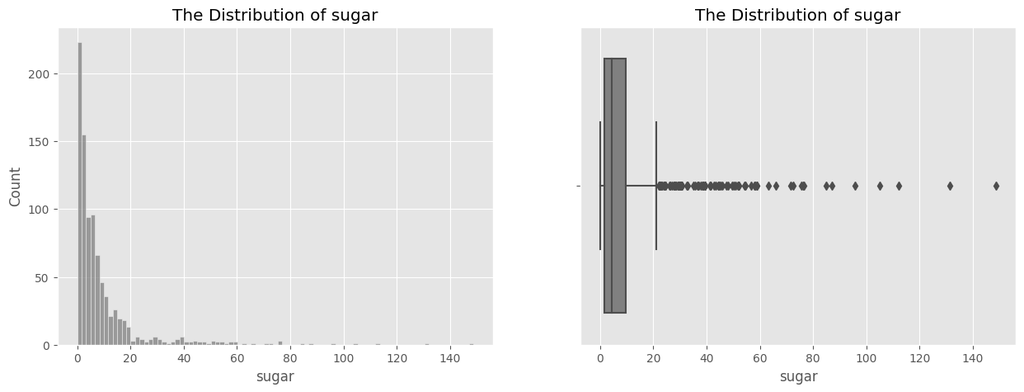

```python
#check sugar variable distribution
fig, axes = plt.subplots(1,2,figsize=(15,5))
sns.histplot(x=df['sugar'],ax=axes[0],color='gray').set(title='The Distribution of sugar')
sns.boxplot(x=df['sugar'],color='gray',ax=axes[1]).set(title='The Distribution of sugar');
```

```python
#impute median for sugar variable missing values
df.loc[df['sugar'].isnull(),'sugar']=df['sugar'].median()
df.sugar.isna().sum()
```

```
0
```

```python
#check number of missing values in the protein variable
df.protein.isna().sum()
```

```
52
```

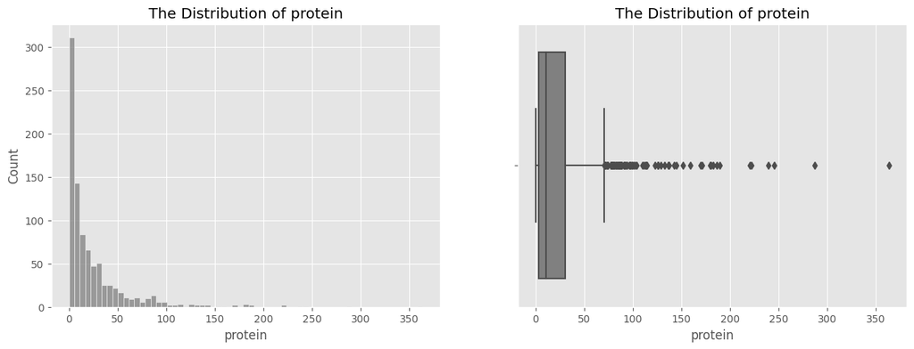

```python
#check protein variable distribution
fig, axes = plt.subplots(1,2,figsize=(15,5))
sns.histplot(x=df['protein'],ax=axes[0],color='gray').set(title='The Distribution of protein')
sns.boxplot(x=df['protein'],color='gray',ax=axes[1]).set(title='The Distribution of protein');
```

```python
#impute median for protein variable missing values
df.loc[df['protein'].isnull(),'protein']=df['protein'].median()
df.protein.isna().sum()
```

```
0
```

```python
#check unique category variable
df.category.unique()
```

```
array(['Pork', 'Potato', 'Breakfast', 'Beverages', 'One Dish Meal',
       'Chicken Breast', 'Lunch/Snacks', 'Chicken', 'Vegetable', 'Meat',
       'Dessert'], dtype=object)
```

```python
df['category'] = df['category'].replace(['Chicken Breast'], ['Chicken'])
df['category'].value_counts()
```

```
Chicken          172
Breakfast        106
Beverages         92
Lunch/Snacks      89
Potato            88
Pork              84
Vegetable         83
Dessert           83
Meat              79
One Dish Meal     71
Name: category, dtype: int64
```

```python
df['category']=df['category'].astype('category')
df['category'].dtype
```

```
CategoricalDtype(categories=['Beverages', 'Breakfast', 'Chicken', 'Dessert',
                  'Lunch/Snacks', 'Meat', 'One Dish Meal', 'Pork', 'Potato',
                  'Vegetable'],
, ordered=False)
```

```python
#check unique servings variable
df['servings'].value_counts()
```

```
4               389
6               197
2               183
1               175
4 as a snack      2
6 as a snack      1
Name: servings, dtype: int64
```

```python
#replace mispelled values with the correct string
df['servings'] = df['servings'].replace(['4 as a snack','6 as a snack'], ['4','6'])
df['servings'].value_counts()
```

```
4    391
6    198
2    183
1    175
Name: servings, dtype: int64
```

```python
#convert servings dtype to int
df['servings']=df['servings'].astype('int')
df['servings'].dtype
```

```
dtype('int64')
```

```python
#check high_traffic values
df.high_traffic.value_counts(dropna=False)
```

```
High    574
NaN     373
Name: high_traffic, dtype: int64
```

```python
df['high_traffic'].fillna(0, inplace=True)
df['high_traffic'] = df['high_traffic'].replace(['High'], [1])
df.high_traffic.value_counts()
```

```
1    574
0    373
Name: high_traffic, dtype: int64
```

```python
df.info()
```

```
<class 'pandas.core.frame.DataFrame'>
RangeIndex: 947 entries, 0 to 946
Data columns (total 8 columns):
 #   Column        Non-Null Count  Dtype
---  ------        --------------  -----
 0   recipe        947 non-null    int64
 1   calories      947 non-null    float64
 2   carbohydrate  947 non-null    float64
 3   sugar         947 non-null    float64
 4   protein       947 non-null    float64
 5   category      947 non-null    category
 6   servings      947 non-null    int64
 7   high_traffic  947 non-null    int64
dtypes: category(1), float64(4), int64(3)
memory usage: 53.2 KB
```

## Exploratory analysis

### Target variable - high_traffic

Since we need to predict the traffic, the high_traffic variable will be our target variable. From the countplot we can see that the target variable is a bit unbalanced, aproximately 3/5 of the recipes have high traffic.

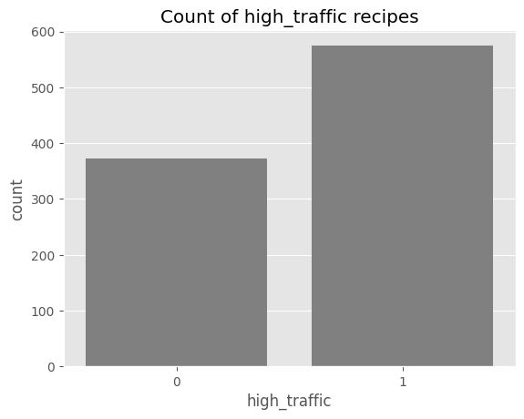

```python
sns.countplot(x=df['high_traffic'], color='gray')\
.set(title='Count of high_traffic recipes');
```

### Correlation Numeric variables - calories, carbohydrate, sugar, protein, servings, high_traffic

From the heatmap below, we can conclude that there is a low linear relationship in the pair calories - protein. No numeric variable is correlated with the target.

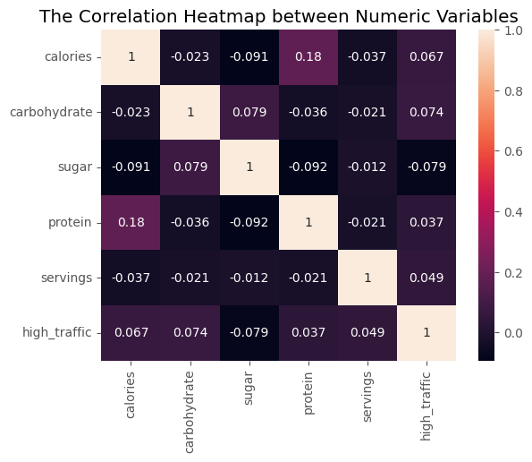

```python
numeric = df[['calories','carbohydrate','sugar','protein','servings', 'high_traffic']]
sns.heatmap(numeric.corr(),annot=True).set(title='The Correlation Heatmap between Numeric Variables');
```

### Distribution continuous variables - calories, carbohydrate, sugar, protein

As we can see, all these variables have a right skewed distribution. Further below we can see how applying a log transformation to the variables makes the data more suitable to modeling.

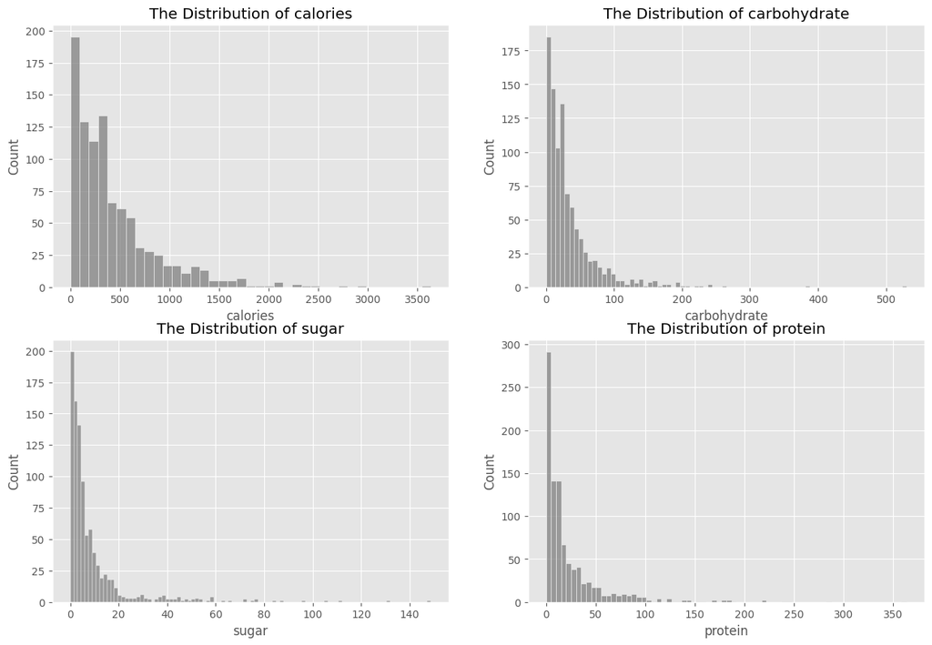

```python
fig, axes = plt.subplots(2,2,figsize=(15,10))
sns.histplot(x=df['calories'],ax=axes[0,0],color='gray').set(title='The Distribution of calories')
sns.histplot(x=df['carbohydrate'],ax=axes[0,1],color='gray').set(title='The Distribution of carbohydrate')
sns.histplot(x=df['sugar'],ax=axes[1,0],color='gray').set(title='The Distribution of sugar')
sns.histplot(x=df['protein'],ax=axes[1,1],color='gray').set(title='The Distribution of protein');
```

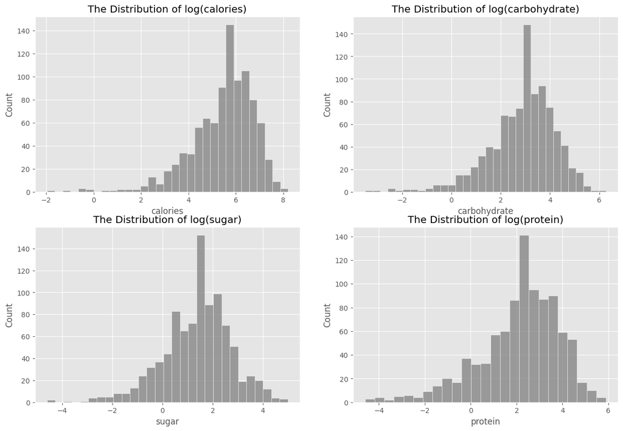

```python
fig, axes = plt.subplots(2,2,figsize=(15,10))
sns.histplot(x=np.log(df['calories']),ax=axes[0,0],color='gray').set(title='The Distribution of log(calories)')
sns.histplot(x=np.log(df['carbohydrate']),ax=axes[0,1],color='gray').set(title='The Distribution of log(carbohydrate)')
sns.histplot(x=np.log(df['sugar']),ax=axes[1,0],color='gray').set(title='The Distribution of log(sugar)')
sns.histplot(x=np.log(df['protein']),ax=axes[1,1],color='gray').set(title='The Distribution of log(protein)');
```

### Combination of 2 numeric variables and the target

From the pairwise plot below I have also investigated whether any 2D plot of 2 numeric variables has regions of high density of a specific target label that would have enabled the creation of additional features (feature engineering) but it is not the case.

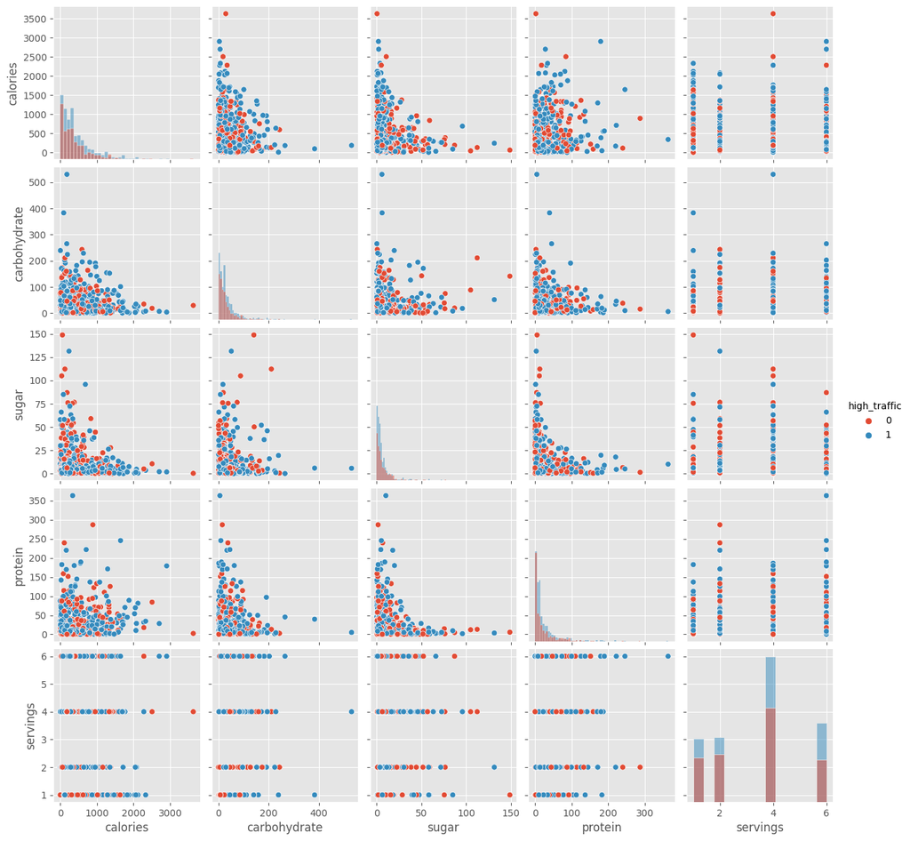

```python
sns.pairplot(df, hue='high_traffic',vars=['calories','carbohydrate','sugar','protein','servings'], diag_kind='hist');
```

### Relationship between traffic per category and servings per category

I checked the relationship of the target and the categorical variable **category**. From the bar chart below to the left, we can see that the most common category is chicken, other common categories such as Pork, Potato and Vegetable tend to have high traffic almost always, on the other hand, Beverage almost never has high traffic. These categories are very discriminative so this variable is relevant for modeling.

In the bar char below to the right, we can see that the proportional pattern of servings per category is similar across all categories.

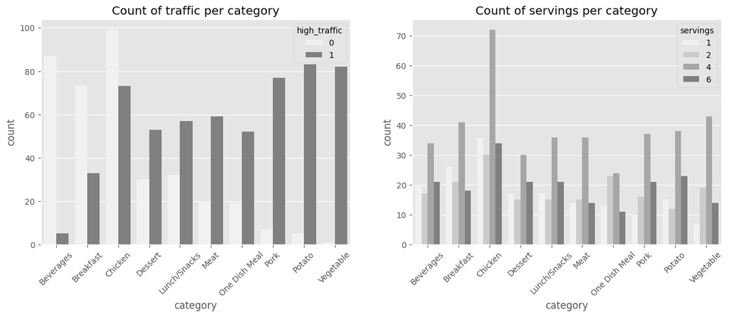

```python
fig, axes = plt.subplots(1,2,figsize=(15,5))
sns.countplot(x=df['category'],hue=df['high_traffic'],ax=axes[0],color='gray').set(title='Count of traffic per category')
sns.countplot(x=df['category'],hue=df['servings'],ax=axes[1],color='gray').set(title='Count of servings per category')
axes[0].tick_params(axis='x', labelrotation=45)
axes[1].tick_params(axis='x', labelrotation=45);
```

## Model Fitting & Evaluation

Predicting which recipes will be popular is a classification problem in machine learning. It is a **binary classification problem** since the target variable has only **2 possible outputs**.

I am choosing the **Gaussian Naive Bayes Classifier** because it is a simple model that assumes feature independence between classes, that is null correlation between the features and the target, it also does not require the data to be standardized, is efficient to train and generally produces good results. The comparision model I am choosing is the **Random Forest Classifier** because tree models can capture non-linear relationships between explanatory variables and the target variable very accurately, also ensemble methods are more robust to overfitting.

For the evaluation, I am choosing **Precision** and **Recall** to evaluate the model. Recall minimizes the number of **False Negatives** that is equivalent to increase the number of **True Positives** (absolute number of high traffic recipes predicted correctly) while precision minimizes the number of **False Positives**, we want a **Precision>=0.8** since we want high traffic predicted recipes to be correct 80% of the time.

### Prepare Data for Modelling

To enable modelling, we chose calories,carbohydrate,sugar,protein,category,servings as features and high_traffic as target variable. I also have made the following changes:

- Replace outliers in numerical columns with the median and apply a log transformation.
- Convert the categorical variables into numeric features
- Split the data into a training set and a test set, using stratified method.

```python
from sklearn.model_selection import train_test_split
from sklearn.naive_bayes import GaussianNB
from sklearn.ensemble import RandomForestClassifier
from sklearn.metrics import recall_score, precision_score
```

First I define a function that returns the lowerbound and upperbound of a numeric column. Then I apply it to the numeric columns:

```python
def outlier_detector(datacolumn):
    Q1,Q3 = np.percentile(datacolumn,[25,75])
    IQR = Q3 - Q1
    lower_bound = Q1-(1.5*IQR)
    upper_bound = Q3+(1.5*IQR)
    return lower_bound,upper_bound
```

```python
numeric=['calories','carbohydrate','sugar','protein']
for i in numeric:
    lowerbound, upperbound = outlier_detector(df[i])
    median = df[i].median()
    df.loc[((df[i] > upperbound)|(df[i] < lowerbound)), i] = median
```

```python
for i in numeric:
    df[i]=np.log(df[i]+1)
```

```python
X = df.iloc[:, 1:-1]
y = df.iloc[:, -1]
```

```python
X_onehot = pd.get_dummies(X, columns=['category'],drop_first=True)
```

```python
X_train, X_test, y_train, y_test = train_test_split(X_onehot, y, test_size=0.3,
                                                    random_state=42, stratify=y)
```

### Gaussian Naive Bayes Classifier model

```python
gb = GaussianNB()
gb.fit(X_train, y_train)
```

```
GaussianNB()
```

```python
y_pred = gb.predict(X_test)
print('Gaussian Naive Bayes recall: ',recall_score(y_test,y_pred))
print('Gaussian Naive Bayes precision: ',precision_score(y_test,y_pred))
```

```
Gaussian Naive Bayes recall:  0.5664739884393064
Gaussian Naive Bayes precision:  0.8990825688073395
```

### Random Forest Classifier Model

```python
#RandomForestClassifier
rf = RandomForestClassifier(max_depth=7,random_state=7)
rf.fit(X_train,y_train)
y_pred2 = rf.predict(X_test)
```

```python
print('Random Forest Classifier recall: ',recall_score(y_test,y_pred2))
print('Random Forest Classifier precision: ',precision_score(y_test,y_pred2))
```

```
Random Forest Classifier recall:  0.815028901734104
Random Forest Classifier precision:  0.8011363636363636
```

#### Finding the best parameter for Random Forest Classifier Model

```
Best max_depth is: 8
Testing precision is: 0.8208092485549133
```

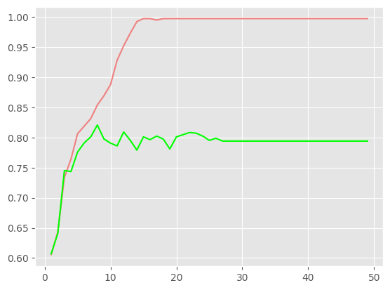

```python
train_score = []
test_score = []
max_score = 0
max_pair = (0,0)

for i in range(1,50):
    rf = RandomForestClassifier(max_depth=i,random_state=7)
    rf.fit(X_train,y_train)
    y_pred_test = rf.predict(X_test)
    y_pred_train = rf.predict(X_train)
    train_score.append(precision_score(y_train,y_pred_train))
    test_score.append(precision_score(y_test,y_pred_test))
    test_pair = (i,precision_score(y_test,y_pred_test))
    if test_pair[1] > max_pair[1]:
        max_pair = test_pair
        best_rf = rf

fig, ax = plt.subplots()
ax.plot(np.arange(1,50), train_score, label = "Training precision",color='lightcoral')
ax.plot(np.arange(1,50), test_score, label = "Testing precision",color='lime')
print(f'Best max_depth is: {max_pair[0]} \nTesting precision is: {max_pair[1]}')
```

#### Finding feature importance

As we saw in the EDA section, Potato, Vegetable, Chicken and Pork are among the most important categories.

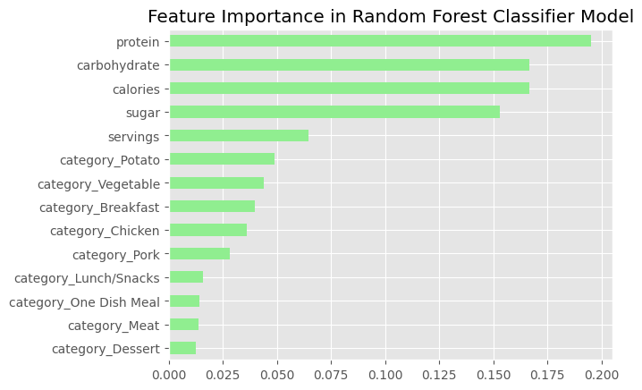

```python
importances_rf=pd.Series(rf.feature_importances_,index=X_train.columns)
sorted_importances_rf=importances_rf.sort_values()
sorted_importances_rf.plot(kind='barh',color='lightgreen',title='Feature Importance in Random Forest Classifier Model')
plt.show()
```

## Results

The Recall of the Gaussian Naive Bayes, and the Random Forest Classifier model is 0.57 and 0.82, meaning the **Random Forest Classifier model predicts a higher absolute number of high traffic recipes which are actually high traffic recipes.** The Precision of the Gaussian Naive Bayes, and the Random Forest Classifier model is 0.9 and 0.82, meaning the **Gaussian Naive Bayes predicts a higher percentage of correctly predicted high traffic recipes .**

### Evaluate by Business Criteria

The company wants to predict which recipes will lead to high traffic and also ensure that the predictions are correct 80% of the time. Therefore, we would consider using **Recall and Pecision as KPIs**, precision of predictions should be higher than 80% all the time to ensure that at least 80% of high traffic recipes predicted are correct while we should monitor recall to check the ability of the model to discriminate a high percentage of high traffic recipes.

Both models reach the **80% Precision threshold**, Gaussian Naive Bayes has a precision of 90% while the random forest classifier reaches 82%. Random Forest Classifier achieves a Recall of 82% while Gaussian Naive Bayes only reaches 57% so random forest performs much better on that metric.

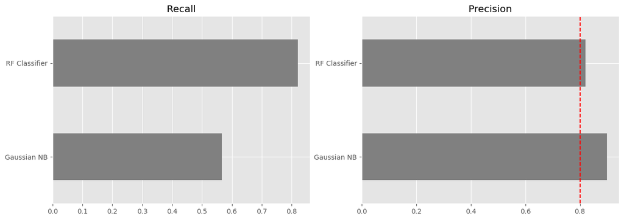

```python
labels = ['Gaussian NB', 'RF Classifier']
recall = [recall_score(y_test,y_pred), recall_score(y_test,best_rf.predict(X_test))]
precision = [precision_score(y_test,y_pred), precision_score(y_test,best_rf.predict(X_test))]
fig, axes = plt.subplots(1,2,figsize=(15,5))
recall_plot=pd.Series(recall,index=labels)
#sorted_importances_rf=importances_rf.sort_values()
recall_plot.plot(kind='barh',color='gray',title='Recall',ax=axes[0])
precision_plot=pd.Series(precision,index=labels)
precision_plot.plot(kind='barh',color='gray',title='Precision',ax=axes[1])
axes[1].axvline(x=0.8, color='red', linestyle='--')
plt.show()
```

## Recommendation

To ensure that only high traffic recipes are displayed on the homepage each day we can plan to deploy this **Random Forest Classifier** into production. By implementing this model, above 80% of the high traffic recipes predicted will generate high traffic on the website. This will increase the subscriptions and generate more revenue. I will recommend the following steps to ensure the model can be deployed and improved regularly.

1. Test the model in the recent month and compare the traffic on the website with respect to the previous month.
2. Identify and fix errors to improve recall and precision after testing.
3. Fully deploy the model using an efficient deployment strategy, such as a web or mobile application or API.
4. Continuously improve the model by collecting more data, feature engineer and fine tuning parameter. This would be the key points to maintain a high precision in the predictions over time while continuing achieving a high recall.